# Velferdsstatens framtid

NOU 2021:9, kap.4

Mikko Moilanen

29/04/2026

## Velferdsstatens fremtid

- stort behov for arbeidskraft i årene som kommer

[figure not shown]

- den demografiske utviklingen fører til lavere vekst i arbeidsstyrken og skatteinntektene

[figure not shown]

## Inntektene fra oljevirksomheten er ventet å gå ned

[figure not shown]

Produksjon og anslått fremtidig produksjon av petroleum på norsk sokkel. Mill. Sm3 oljeekvivalenter. Kilder: Energidepartementet og Sokkeldirektoratet

[figure not shown]

Statens netto kontantstrøm fra petroleumsvirksomheten. Andel av BNP for Fastlands-Norge. Prosent. Kilde: Finansdepartementet

## Summa summarum

- presset på offentlige finanser øker
- aldringen av befolkningen gir økt behov for arbeidskraft i helse- og omsorgssektoren
- modellen må kontinuerlig vurderes, utvikles og styrkes

## Den norske modellen er helt avhengig av **høy yrkesdeltakelse**

- den norske modellen er helt avhengig av **høy yrkesdeltakelse** for å kunne finansiere velferdsordningene framover
  - sysselsettingen faller etter fylte 62 år
    - jo flere eldre i arbeidsstyrken → reduserer sysselsettingsandelen
    - internasjonale trender (teknologisk utvikling og (anti-)globalisering) vil føre til at jobber både forsvinner og blir skapt
      - nettoeffekten er usikker
        - de nye jobbene vil sannsynligvis kreve mer kompetanse enn jobbene som forsvinner
          - vanskeligere å inkludere sårbare grupper
  - nedbygging av petroleumssektoren vil også innebære omstillingsbehov
    - endringer i etterspørselen etter ulike typer arbeidskraft
    - kan svekke sysselsettingen, særlig i omstillingsfasen

## Økt press på offentlige finanser i årene fremover

- veksten i underliggende skatteinntekter avtar som følge av lavere befolkningsvekst og aldring

[figure not shown]

Netto overføringer fra offentlig forvaltning etter alder. 1 000 2024-kroner. Basert på tallgrunnlag fra 2017. Omregnet til 2024-priser ved hjelp av utgiftsdeflatoren for statsbudsjettet. Kilder: Statistisk sentralbyrå og Finansdepartementet.

- innfasingen av oljepengebruk vil være betydelig lavere framover
  - inntektene fra olje- og gassvirksomheten vil avta
- aldringen av befolkningen øker utgiftene til alderspensjon og helse- og omsorgstjenester
- På lengre sikt
  - lavere inntekter og høyere utgifter fører til et **inndekningsbehov i offentlige finanser**
- fire ulike strategier for å dekke inndekningsbehovet (Perspektivmeldingen 2017)
  - økt sysselsetting
    - det mest attraktive alternativet
      - økt verdiskaping
      - økte inntekter
      - reduserte utgifter
      - gunstig for individer som kommer i arbeid
  - mer effektiv ressursbruk i offentlig sektor
    - **kutt i budsjettene** i offentlig sektor tilsvarende anslått produktivitetsvekst
      - budsjettinnstramminger utover produktivitetsvekst vil svekke kvaliteten på tjenestene
    - lite sannsynlig at mer effektiv ressursbruk i offentlig sektor alene skal kunne dekke det framtidige inndekningsbehovet
  - økt privat ansvar
    - økt privat medfinansiering av offentlige tjenester
    - ansvaret for tjenester overføres til privat sektor
    - økte brukerbetalinger (har uheldige fordelingsmessige konsekvenser)
    - politisk krevende å gjennomføre
  - økte skatter
    - betydelig økning i skattenivået
      - negative effekter på arbeidstilbudet og på bedriftenes insentiver til å investere og drive næringsvirksomhet
    - bekjempelse av skatteunndragelse og et mer effektivt skattesystem kan bidra til å bedre ressursutnyttelsen

## Økt behov for arbeidskraft i helse- og omsorgssektoren

- Aldringen av befolkningen → ressursbruken i helse- og omsorgssektoren øker → økt behov for arbeidskraft
- For å møte behovet for arbeidskraft vil det måtte være 15 prosent av sysselsatte i helse- og omsorgssektoren i 2035, og 22 prosent i 2060 (Hjemås m.fl. 2019)
  - vil være en fjerdedel av den totale sysselsettingsveksten fram til 2035, og halvparten mellom 2035 og 2060
- faktorer som bremser etterspørselsveksten
  - bedre helse blant eldre
  - økt bruk av velferdsteknologi øker produktiviteten
- faktorer som øker etterspørselsveksten etter arbeidskraft i sektoren
  - økt standard på helsetjenestene
  - økt velstandsnivå gir forventning om stadig bedre tjenester
  - nye og kostbare behandlingsmuligheter blir tilgjengelig
- etterspørselen etter arbeidskraft vil trolig også øke i andre sektorer (Cappelen m.fl. 2020)
  - etterspørselen vil vokse klart sterkere enn arbeidsstyrken for personer med videregående fagutdanning rettet inn mot industri, bygg og anlegg og håndverk

# Sysselsetting og megatrender

## Automatisering og teknologisk utvikling

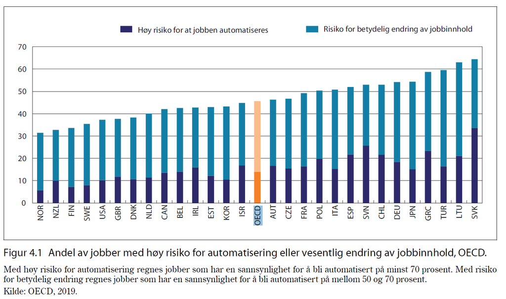

- Teknologisk utvikling har både positive og negative effekter på sysselsettingen
  - **teknologi erstatter mennesker** i utførelsen av oppgaver
    - **negativ effekt på sysselsettingen**
    - økt produktivitet → prisreduksjoner → økt etterspørsel → **positiv effekt** på sysselsettingen
  - **ny teknologi komplementerer menneskelig arbeidskraft** → øker produktiviteten til arbeidstakere
    - innovasjon → nye produkter og teknologi → økt produktivitet → lønningene opp og prisene ned → økt kjøpekraft, økte investeringer og økt etterspørsel etter arbeidskraft → nye arbeidsplasser
    - **positive sysselsettingseffekter**
  - ny teknologi kan også skape helt nye jobber

[figure not shown]

Arbeidere i yrker med størst mulighet for automatisering, som prosent av samlet sysselsetting. 2019. Kilde: OECD (2023). Employment Outlook 2023.

- Totaleffekten avhenger hvilken effekt som er sterkest
  - “Ny teknologi og arbeidskraft er komplementer”:
    - Atkinson og Wu(2017), Marcussen (2016):
      - frykten for teknologidrevet ledighet er sterkt overdrevet
      - takten i yrkesmobilitet og jobbtap under de seinere års tekniske rasjonalisering har vært lav de senere årene
  - “Ny teknologi og arbeid er substitutter”:
    - maskinlæring, automatisering, roboter og andre digitale verktøy gjør arbeidskraft overflødig
      - spesielt innenfor rutinepregede aktiviteter
      - også jobber som hovedsakelig består av kognitive oppgaver og var ansett som umulige å automatisere, er nå i faresonen (Brynjolfsson & McAfee 2014)
- utfordringene automatiseringen skaper må vurderes i forhold til de store endringene som uansett skjer hvert år i arbeidsmarkedet
  - hvert år forsvinner om lag hver tiende jobb, mens enda flere jobber kommer til
- økt polarisering på arbeidsmarkedet: ny teknologi har konsekvenser for hvilke typer jobber som finnes

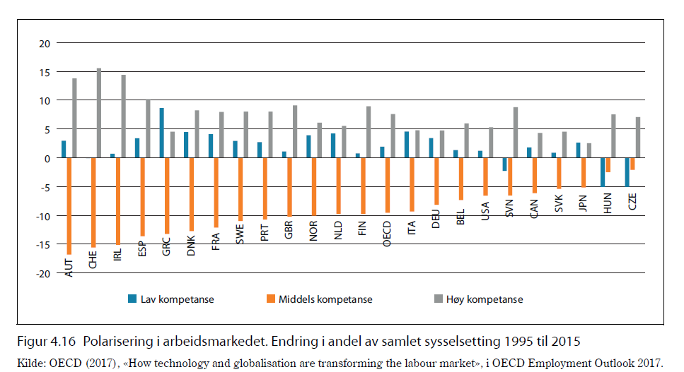

- etterspørselen etter ulike typer arbeidstakere vil ikke være konstant
  - etterspørselen etter arbeidstakere som utfører kognitivt krevende oppgaver øker som følge av informasjonsteknologi
  - noen jobber som krever middels kompetanse står i fare for å bli automatisert bort
  - mange jobber i tjenestesektoren er vanskelig å automatisere

## Globalisering (eller antiglobalisering?)

- Små, åpne vestlige økonomier har høstet store gevinster av liberaliseringen av internasjonal handel i etterkrigstiden
  - globalisering av finanssektoren har derimot hatt mer tvetydige virkninger
- Selv om de nordiske økonomiene har vært blant globaliseringsvinnerne, har arbeidsplasser i flere bransjer og næringer gått tapt
  - omstrukturering av internasjonale produksjons- og verdikjeder har ført til relokalisering av manuelle jobber
    - parallelt med vekst i kunnskapsintensive jobber på hjemmebane
- fri bevegelse av tjenester og arbeidskraft får økende betydning for vekst- og omstillingsevnen i arbeidslivet
  - norsk eksport til EU dominert av olje, gass, ubearbeidet fisk og råvarebaserte industriprodukter
    - Hvis målet i framtiden er å utvikle mer kunnskapsbasert digital, grønn eksportproduksjon med større innslag av tjenester, vil det økonomisk sett neppe være noen fordel om Norge stiller seg utenfor EU
- lavere kommunikasjons- og transportkostnader har knyttet sammen markeder for varer og tjenester
- har bidratt til akselererende spredning av teknologi og data, informasjon og kunnskapsbaserte tjenester
- flere tjenester kan bli formidlet online uten hensyn til geografisk avstand
  - økt innovasjonstakt og forsterket internasjonal konkurranse
  - et mulig scenario: globalisering innen kunnskapsintensiv produksjon og online-tjenester, utflyttingen av tradisjonell arbeidsintensiv produksjon bremses opp

## Store demografiske endringer: aldring og migrasjon I

- Utviklingen i arbeidsstyrken påvirkes først og fremst av **demografiske endringer**
  - endringer i befolkningens størrelse og alderssammensetting
    - Ifølge beregninger fra Eurostat vil befolkningen i arbeidsdyktig alder (15-64) i EU skrumpe
    - andelen eldre vil øke drastisk de neste 50 årene
    - arbeidsstyrken i EU vil falle med 45 millioner fram til 2080, brorparten før 2050
    - aldersgruppa 65+ øke med 53 millioner fra 19 prosent til 29 prosent av befolkningen
      - størsteparten av veksten vil komme i gruppa 80+
        - mest behov for helse- og omsorgstjenester
    - **den aldersmessige forsørgerbyrden (antall personer 65 år og over delt på antall personer 20-64 år) kommmer til å øke kraftig**

## Forsørgerbrøk for eldre

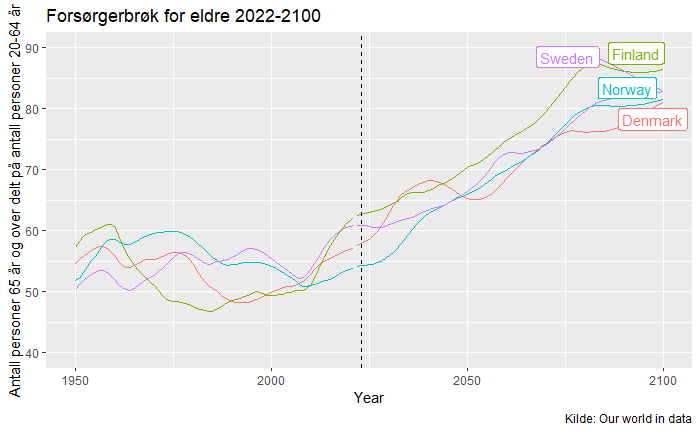

## Grønn omstilling og lavere etterspørsel fra petroleumssektoren

- petroleumsvirksomheten har bidratt betydelig til å løfte verdiskaping, inntekter og velstand i norsk økonomi
- en femtedel av økningen i BNP for Fastlands-Norge fra 2002 kan tilskrives den økte etterspørselen fra petroleumsvirksomheten og bruken av oljeinntekter over statsbudsjettet
- bruken av petroleumsressursene har også påvirket næringsstrukturen
- framover forventes det lavere etterspørsel fra petroleumssektoren
- for å nå klimamålene kreves det tiltak som vil redusere etterspørsel etter norsk olje og gass
  - framskynder nedbyggingen av petroleumssektoren
  - øker utfordringene knyttet til omstillingen av norsk økonomi
    - IEA: har laget et scenario som viser hvilke tiltak som er nødvendige for å nå Paris-avtalens klimamål (International Energy Agency 2020)
      - etterspørselen etter olje og gass vil være henholdsvis 34 og 12 prosent lavere i 2040 enn i 2019

## Hvordan øke sysselsettingen

- høy sysselsetting er et hovedmål i norsk politikk
  - viktig for
    - verdiskapningen
    - finansiering av velferdsordninger
    - den enkeltes velferd
- sysselsettingen i Norge er høy
  - nesten 80 prosent av befolkningen mellom 20 og 64 år er sysselsatt
- Norge har stort behov for arbeidskraft i årene som kommer
  - flere utfordringer knyttet til å øke sysselsettingen
    - skillet mellom de som er innenfor og de som er utenfor arbeidsmarkedet er blitt skarpere over tid
    - blant unge har andelen som mottar langvarige helserelaterte ytelser fra det offentlige økt

[figure not shown]

Økning i antall sysselsatte og antall årsverk ved ulike retningsvalg. 1 000. Full effekt. Kilde: Finansdepartementet.

- Økt sysselsetting kan bare skje i kombinasjon med en god utvikling i norsk økonomi
  - en velfungerende lønnsdannelse
  - et levedyktig arbeids- og næringsliv
  - den generelle økonomiske politikken bidrar til et høyt og stabilt nivå på samlet etterspørsel
- tusenkronersspørsmålene:
  - hvilke tiltak som kan bidra til at flere kommer i arbeid?
  - hvordan få flere til å utnytte sin arbeidsevne?
  - hvordan få flere til å unngå unødig langvarige stønadsforløp?
  - hvordan få færre til å falle utenfor arbeidslivet på en varig stønad?

## Avslutning

- aldrende befolkning gjør at trygdeutgiftene og utgiftene til omsorg og pleie vil stige mye fremover
  - et betydelig økt finansieringsbehov med dagens velferdsstat
  - selv med et stort pensjonsfond er det behov for ytterligere tiltak for å finansiere velferdsstaten
    - øke inntektene (skatter, brukerbetalinger)
    - redusere utgiftene på andre områder